# Rapport de la seconde partie du TP4 de statistique exploratoire

Rémy Gaudré

15/10/2019

## Importation des données

```
## donnees
##
##  14  Variables      27  Observations
## ---------------------------------------------------------------------------
## ORTH
##        n  missing distinct     Info     Mean      Gmd      .05      .10
##       27        0       18    0.997    10.02    5.553     4.50     4.80
##      .25      .50      .75      .90      .95
##     5.75    11.00    14.00    15.50    15.85
##
## Value        0.0   4.5   5.0   5.5   6.0   6.5   7.0   8.5   9.0  11.0
## Frequency      1     2     1     3     1     2     1     1     1     2
## Proportion 0.037 0.074 0.037 0.111 0.037 0.074 0.037 0.037 0.037 0.074
##
## Value       11.5  12.0  13.0  14.0  15.0  15.5  16.0  20.0
## Frequency      1     1     2     2     2     2     1     1
## Proportion 0.037 0.037 0.074 0.074 0.074 0.074 0.037 0.037
## ---------------------------------------------------------------------------
## GRAM
##        n  missing distinct     Info     Mean      Gmd      .05      .10
##       27        0       15    0.989    7.556    3.142     2.95     4.00
##      .25      .50      .75      .90      .95
##     6.50     7.50     8.50    10.80    13.05
##
## Value        2.0   2.5   4.0   4.5   5.5   6.5   7.0   7.5   8.0   8.5
## Frequency      1     1     2     1     1     3     1     4     5     2
## Proportion 0.037 0.037 0.074 0.037 0.037 0.111 0.037 0.148 0.185 0.074
##
## Value        9.0  10.0  12.0  13.5  14.5
## Frequency      2     1     1     1     1
## Proportion 0.074 0.037 0.037 0.037 0.037
## ---------------------------------------------------------------------------
## EXPR
##        n  missing distinct     Info     Mean      Gmd      .05      .10
##       27        0       17    0.993    8.889    3.407      4.8      5.8
##      .25      .50      .75      .90      .95
##      7.5      9.0     10.5     12.2     13.9
##
## Value        2.0   4.5   5.5   6.0   6.5   7.5   8.0   8.5   9.0  10.0
## Frequency      1     1     1     2     1     4     2     1     4     2
```

[output cut: 139 more lines]

```
## Frequency      1     1     1     8     1     4     4     1     1     2
## Proportion 0.037 0.037 0.037 0.296 0.037 0.148 0.148 0.037 0.037 0.074
##
## Value      17.50 18.00
## Frequency      2     1
## Proportion 0.074 0.037
## ---------------------------------------------------------------------------
## EXPO
##        n  missing distinct     Info     Mean      Gmd
##       27        0        9    0.976    14.48    3.963
##
## Value        0.0  13.0  14.0  15.0  16.0  16.5  17.0  17.5  18.0
## Frequency      2     5     1     6     3     1     4     1     4
## Proportion 0.074 0.185 0.037 0.222 0.111 0.037 0.148 0.037 0.148
## ---------------------------------------------------------------------------
```

## Partie A1 : réalisation de l’ACP

Combien de composantes principales peut-on retenir ?

|  | eigenvalue | percentage of variance | cumulative percentage of variance |
| --- | --- | --- | --- |
| comp 1 | 4.7757005 | 34.1121461 | 34.11215 |
| comp 2 | 2.3923845 | 17.0884607 | 51.20061 |
| comp 3 | 1.4993422 | 10.7095870 | 61.91019 |
| comp 4 | 1.3408417 | 9.5774409 | 71.48763 |
| comp 5 | 1.1267019 | 8.0478709 | 79.53551 |
| comp 6 | 0.7203848 | 5.1456057 | 84.68111 |
| comp 7 | 0.5991907 | 4.2799337 | 88.96104 |
| comp 8 | 0.4274849 | 3.0534636 | 92.01451 |
| comp 9 | 0.3904079 | 2.7886277 | 94.80314 |
| comp 10 | 0.2593168 | 1.8522627 | 96.65540 |
| comp 11 | 0.1821002 | 1.3007158 | 97.95611 |
| comp 12 | 0.1255255 | 0.8966105 | 98.85273 |
| comp 13 | 0.0972880 | 0.6949142 | 99.54764 |
| comp 14 | 0.0633305 | 0.4523606 | 100.00000 |

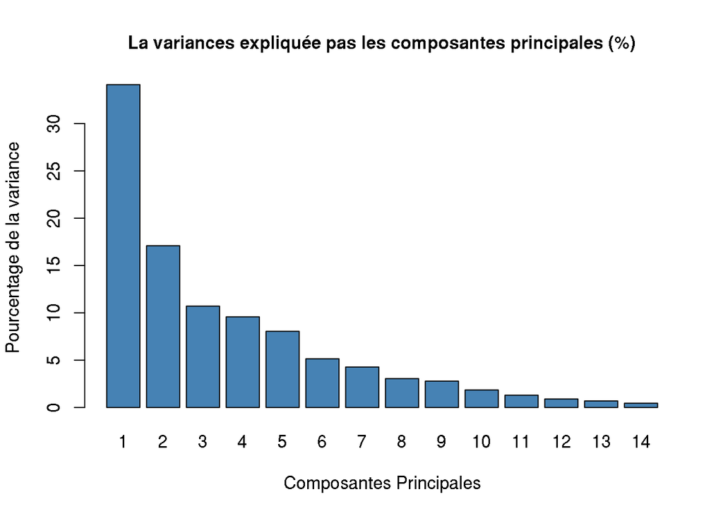

D’après le critère des 80% de variance expliquée : nous avons 6 composantes principales à retenir.  
Le critère du coude nous indique un premier palier à partir de la troisième composante principale et une chute au sixième axe. D’après le critère de Kaiser, nous avons 5 composantes principales à retenir.

## Partie A2 : Réalisation de la classification Ascendante Hiérarchique

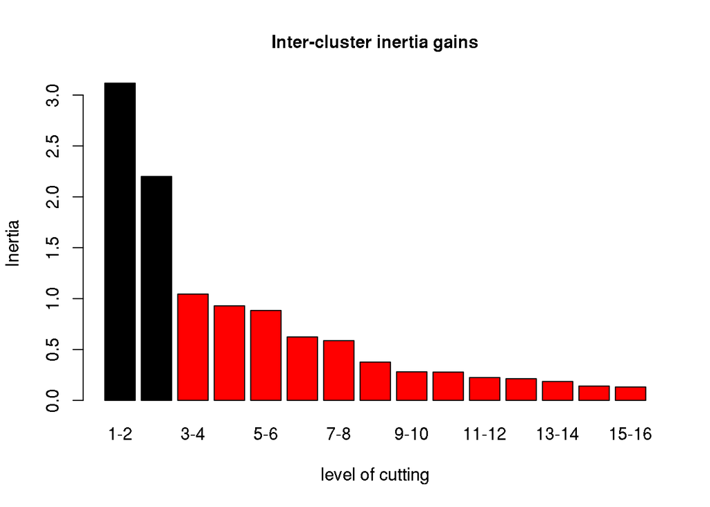

Le nombre de classe optimale est 3.

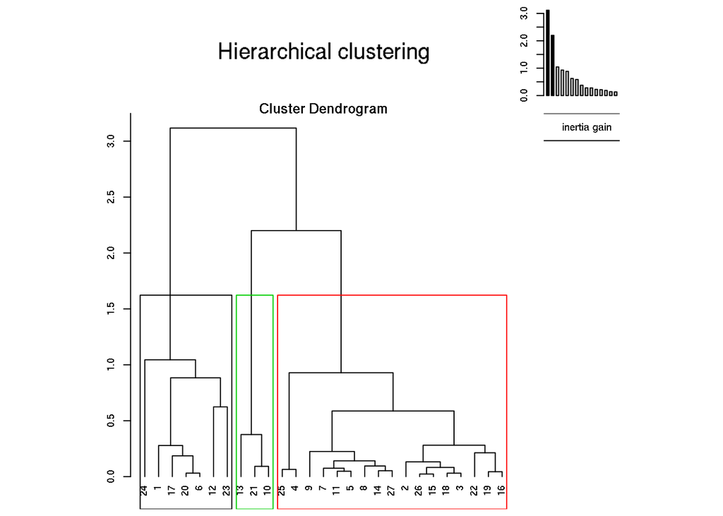

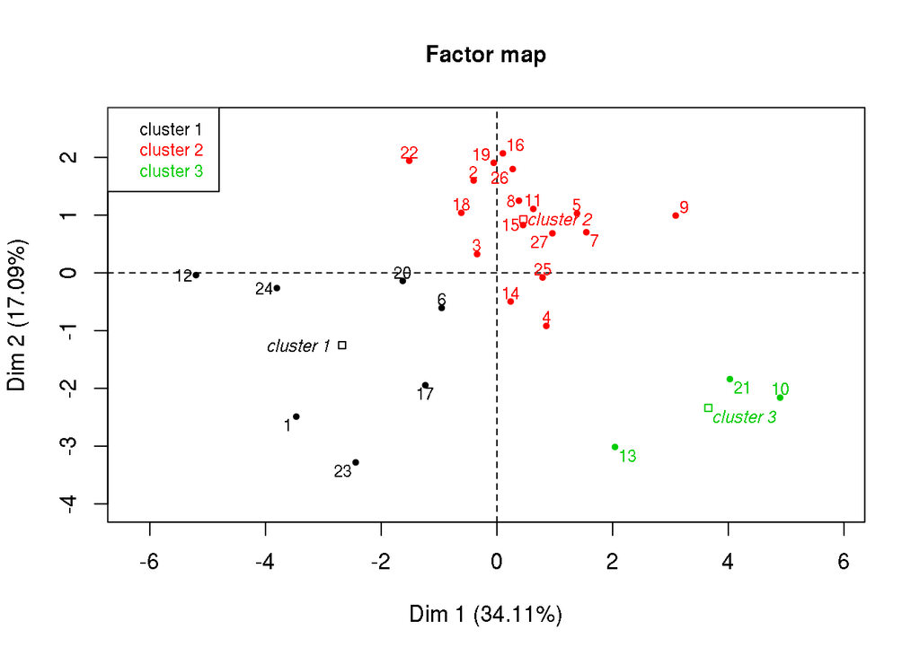

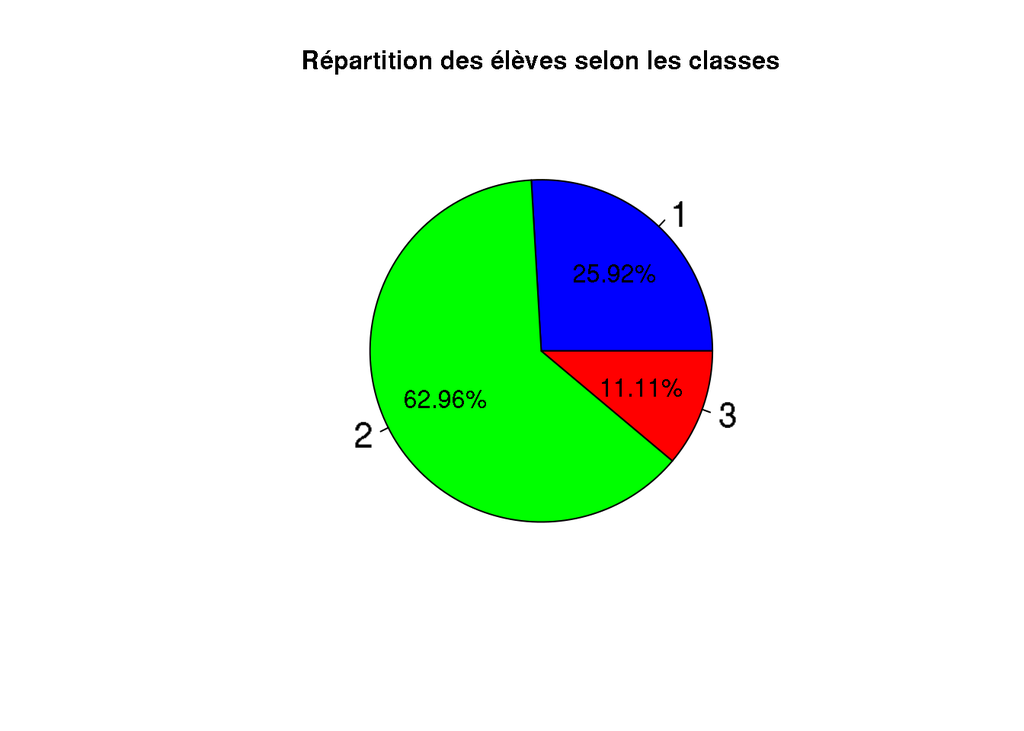

La classe la plus représenté par les élèves est la classe numéro 2 avec plus de la moitié des élèves y appartenant (62.96%). La classe numéro 1 contient 25,92% des élèves et la classe numéro 3 est en minorité avec 11,11% des élèves.

### Etude des élèves

Les matières significatives de la classe 1

|  | v.test | Mean in category | Overall mean | sd in category | Overall sd | p.value |
| --- | --- | --- | --- | --- | --- | --- |
| EXPO | -2.620437 | 10.642857 | 14.481481 | 6.890544 | 4.418986 | 0.0087817 |
| GEO | -2.645103 | 11.000000 | 13.796667 | 4.605897 | 3.189472 | 0.0081666 |
| BIOL | -3.226408 | 5.714286 | 9.592593 | 1.749635 | 3.626132 | 0.0012535 |
| EXPR | -3.420592 | 5.500000 | 8.888889 | 1.732051 | 2.988662 | 0.0006249 |
| ARTS | -3.587296 | 4.428571 | 9.018519 | 2.258770 | 3.859767 | 0.0003341 |
| EDMU | -4.261928 | 10.714286 | 15.203704 | 2.519313 | 3.177640 | 0.0000203 |

Les élèves de la classe 1 ont en général des notes inférieures au reste de la classe. Ils ont des notes en dessous de la moyenne en Exposé, en Géographie, en Biologie, en Expression écrite, en Art plastique et en Education musicale de façon significative. Les matières étant les plus significatives étant l’Education musicale, l’Art plastique, et l’Expression écrite.

Les matières significatives de la classe 2

|  | v.test | Mean in category | Overall mean | sd in category | Overall sd | p.value |
| --- | --- | --- | --- | --- | --- | --- |
| BIOL | 3.065725 | 11.264706 | 9.592593 | 2.926138 | 3.626132 | 0.0021714 |
| EDMU | 2.958275 | 16.617647 | 15.203704 | 1.334270 | 3.177640 | 0.0030937 |
| GEO | 2.386904 | 14.941765 | 13.796667 | 1.570920 | 3.189472 | 0.0169909 |
| ARTS | 2.349155 | 10.382353 | 9.018519 | 2.943235 | 3.859767 | 0.0188161 |
| EPS | 2.238990 | 14.058824 | 13.074074 | 2.078478 | 2.924050 | 0.0251566 |
| RECI | 2.030183 | 11.147059 | 10.074074 | 3.328861 | 3.513739 | 0.0423380 |
| EXPO | 2.019094 | 15.823529 | 14.481481 | 1.790015 | 4.418986 | 0.0434774 |
| GRAM | -2.278116 | 6.588235 | 7.555556 | 2.109051 | 2.822966 | 0.0227197 |

Les élèves de la classe 2 sont généralement des élèves ayant des bonnes notes en Biologie, en Education musicale, en Géographie, en Art plastique, en EPS, en Récitation, et en Exposé de façon significative. Ils ont cependant des lacunes en Grammaire de façon significative. Les matières étant les plus significative de cette classe étant la Biologie et l’Education musicale. Ces élèves sont donc bons dans 7 matières et mauvais dans 1 seule. Les autres matières s’approchant plus de la moyenne de classe.

Les matières significatives de la classe 3

|  | v.test | Mean in category | Overall mean | sd in category | Overall sd | p.value |
| --- | --- | --- | --- | --- | --- | --- |
| GRAM | 3.689750 | 13.33333 | 7.555556 | 1.0274023 | 2.822966 | 0.0002245 |
| EXPR | 3.284116 | 14.33333 | 8.888889 | 1.8408935 | 2.988662 | 0.0010230 |
| ANGL | 3.255989 | 16.83333 | 10.925926 | 0.2357023 | 3.270813 | 0.0011300 |
| MATH | 2.886181 | 17.00000 | 12.574074 | 0.8164966 | 2.764536 | 0.0038995 |
| HIST | 2.847026 | 12.50000 | 9.203704 | 1.7795130 | 2.087260 | 0.0044130 |
| ORTH | 2.725159 | 17.16667 | 10.018519 | 2.0138410 | 4.728717 | 0.0064271 |

Les élèves de la classe 3 sont généralement des élèves littéraires. Ils sont bons en Grammaire, en Expression, en Anglais, en Math, en Histoire et en Orthographe. Les matières les plus significatives de la classe étant la Grammaire, l’Expression écrite et l’Anglais.

### Etude des axes de l’ACP

Les axes significatifs de la classe 1

[output not shown]

Les axes significatifs de la classe 2

[output not shown]

Les axes significatifs de la classe 3

[output not shown]

## Conclusion de la classification ascendante hiérarchique

Pour rappel : on a conclu l’ACP en déterminant que le premier axe de l’ACP déterminait caractérise le niveau de l’élève et le second axe le profil des matières que l’élève réussi le mieux. Les élèves sont réparti dans 3 classes. La première classe contient un quart des élèves. Les élèves de cette classe ont en moyenne des notes assez faibles en Exposé, en Géographie, en Biologie, en Expression écrite en Art Plastique et en Education musicale. Ils ont sont aussi caractérisés par des valeures faibles sur les 2 premiers axes de l’ACP. Les élèves de la première classe sont en général en difficulté.  
Les élèves de la seconde classe sont en moyenne bons en biologie, en éducation musicale, en géographie en art plastique, en EPS, en récitation et en exposé. Ils sont cependant mauvais en grammaire en moyenne. Ils sont aussi caractérisé par une forte valeur sur l’axe 2 de l’acp. C’est élèves sont bons dans 7 des 14 matières et mauvais dans 1 seule. Cette classe représente la majorité des élèves (63% de la classe). Les élèves de la troisième classe ont en moyenne des bonnnes notes en grammaire, en expression, en anglais, en mathématique, en histoire et en orthographe. Ils ont donc un profil plus “littéraire”. Ce qui est confirmé par la bonne valeure moyenne sur l’axe 1 et la faible valeure moyenne sur l’axe 2 de l’ACP. Ils sont plus atypique car seulement 11,11% des élèves sont dans cette classe.